# instructor recap notes - lec 18

#### 2.3 Arithmetic with date-time data

1. **Duration:**
   - Create a duration object, which represents a time span.

```r
   dur <- ddays(1) + dhours(3)  # 1 day and 3 hours
```

2. **Period:**
   - Create a period object, which represents a time span in human terms (days, months, etc.).

```r
   per <- days(1) + months(1)  # 1 month and 1 day
```

3. **Date-time arithmetic:**
   - Add or subtract duration or period objects from date-time objects.

```r
   date + dur  # add duration
```

```
## [1] "2023-10-26 03:00:00 UTC"
```

```r
   date + per  # add period
```

```
## [1] "2023-11-26"
```

#### 2.3 Plot

# Create a dataset

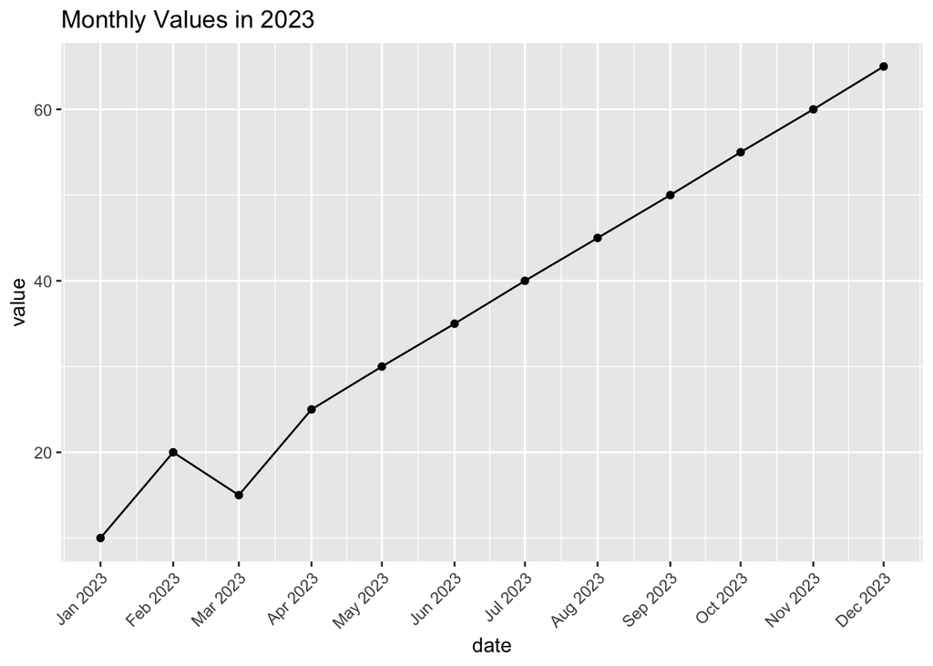

```r
data <- data.frame(
  Date = seq(as.Date("2023-01-01"), by = "month", length.out = 12),
  Value = c(10, 20, 15, 25, 30, 35, 40, 45, 50, 55, 60, 65)
)

# Create the plot
data %>% ggplot(aes(x = Date, y = Value)) +
  geom_line() +  # Line plot
  geom_point() +  # Points
  labs(
    title = "Monthly Values in 2023",
    x = "Date",
    y = "Value"
  ) +
  scale_x_date(date_breaks = "1 month", date_labels = "%b %Y") +  # Format x-axis dates
  theme(axis.text.x = element_text(angle = 45, hjust = 1)) + # Adjust x ticks orientation
  labs(x = "date",
       y = "value")
```

### 3. Today’s lecture

- HW3 released; Due Nov 5 (2 late days)
- Midterm to be released on Nov 8 (due Nov 22) **no free late days**
- Final project options released on our [course website](https://coredatascience-fa23.github.io/project/). Follow the instructions and fill out the [preference form](https://docs.google.com/forms/d/e/1FAIpQLSfvhegiqPG-jQtQvqaIz6jnyLrSv-sOpiF4V3qvQdSTMHK3zQ/viewform) by **Nov 6**.
- Find a time (office hours preferably) to meet with TF (20 minutes) before Nov 17 to review your project.
- Today: New module: probability and regression (yay!)
- Lab this Friday: more practices on advanced data wrangling